# US Loan Default Analysis

A Report for the Credit Institute of Texas

Student 26572982

June 18, 2026

# 1 Executive Summary

This report analyses 1 million peer-to-peer loans from Lending Club to identify key drivers of loan default and evaluate the Credit Institute’s long-held heuristics about borrower risk. Of the 383,202 resolved loans analysed, **22.5% ended in default** — nearly 1 in 4.

**Key findings:**

- Credit grade is the strongest and most reliable predictor of default risk
- DTI above 20 consistently produces above-average default rates — a hard cap of 20 is recommended
- The Institute’s heuristics about home ownership and employment length are only weakly supported
- Texas is unremarkable compared to other US states — no evidence of a distinct default culture
- Small business loans carry the highest default risk at 33.3% — 1 in 3 loans lost
- Interest rates are driven by credit grade, not age or occupation

# 2 Data Overview

| Item | Detail |
| --- | --- |
| Source | Lending Club peer-to-peer lending platform (anonymised) |
| Total loans | 1,000,000 |
| Resolved loans analysed | 383,202 (Defaulted + Fully Paid) |
| Overall default rate | 22.5% |
| Loan amounts | $1,000 to $40,000 |
| Interest rates | 5.31% to 30.99% |
| States covered | All 50 US states |

**Note on methodology:** Analysis was restricted to resolved loans (Defaulted and Fully Paid) only. Current loans (597,668) were excluded as their outcome is unknown. At Risk loans (19,130) were excluded to keep the binary default comparison clean and conservative.

# 3 Default Rate by Credit Grade

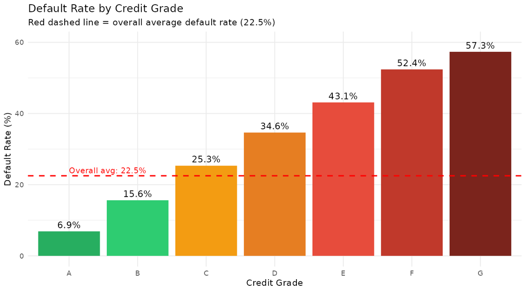

Default rate rises consistently from Grade A (6.9%) to Grade G (57.3%).

**Findings:**

- The Lending Club grading system produces a **perfect staircase pattern** — every grade is worse than the one before without exception
- **Grade A (6.9%) and Grade B (15.6%)** are well below the 22.5% average — genuinely safe lending zones
- **Grade C (25.3%) is the inflection point** — the first grade to cross above the average
- **Grades E, F, G are extreme risk** — more than 1 in 2 Grade F and G loans are lost
- Within each grade, defaulted and fully paid borrowers received virtually identical interest rates — confirming the grade drives pricing, not outcome

**Recommendation:** Prioritise Grade A and B loans. Exercise extreme caution with Grade E and above where default rates exceed 43%.

# 4 Testing the Institute’s Heuristics

## 4.1 Heuristic 1: Home Owners Default Less

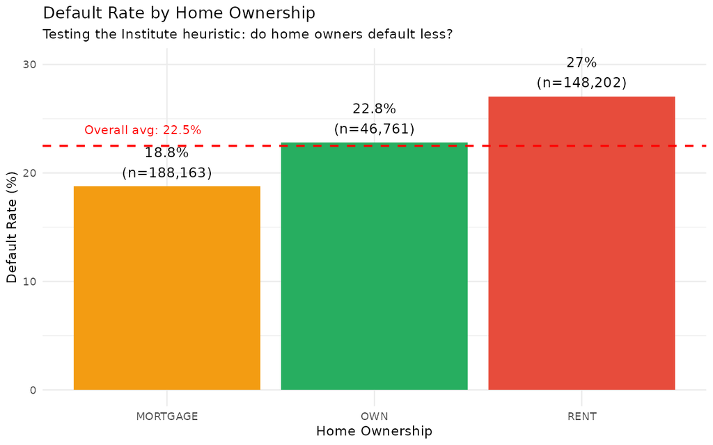

Mortgage holders default least. Renters default most. Outright owners show no advantage.

## 4.2 Heuristic 2: 10+ Years Employment Means Lower Default

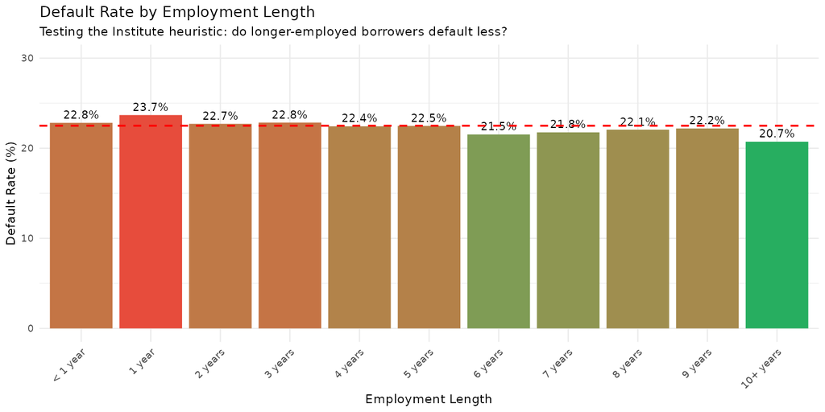

Employment length shows minimal variation in default rates across all categories.

**Findings:**

- **10+ years (20.7%)** does show the lowest default rate — but only 1.8 percentage points below average
- The spread across all employment lengths is only **3 percentage points** (20.7% to 23.7%)
- The pattern is essentially flat — employment length explains very little variation in default risk

**Verdict:** *Not supported as a strong predictor.* While 10+ year employees show slightly lower default rates, the effect is too small to be a reliable screening tool. Employment length alone should not be used as a primary risk indicator.

# 5 DTI Analysis and Hard Cap Recommendation

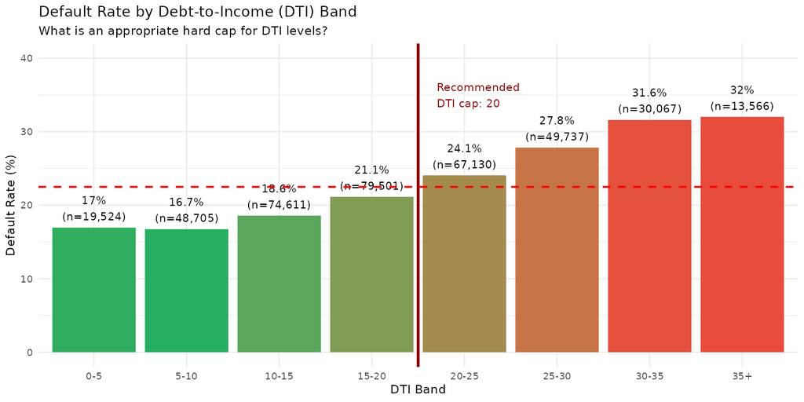

**What is DTI?** The Debt-to-Income ratio measures the percentage of a borrower’s gross monthly income that goes toward existing debt obligations. A high DTI means the borrower is already heavily committed before taking a new loan, leaving little buffer for unexpected expenses.

**DTI Hard Cap Recommendations by Risk Tolerance:**

| Risk Tolerance | Recommended DTI Cap | Expected Default Rate |
| --- | --- | --- |
| Conservative | 20 | Below 21% |
| Moderate | 25 | Below 25% |
| Aggressive | 30 | Below 28% |
| Avoid | Above 30 | 31-32% |

**Does DTI cap differ by state?** Given that Texas and most states cluster around the national average, a uniform DTI cap of 20 is recommended nationally. State-specific adjustments are not warranted given the narrow spread in state-level default rates.

# 6 State Analysis: Is Texas Different?

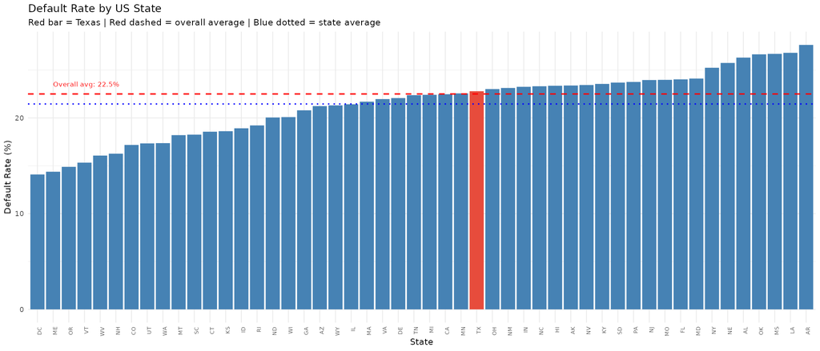

Texas (red bar) sits at the national average. No evidence of a distinct default culture.

**Verdict:** *Texas is not different.* The data does not support the notion that US states differ significantly in their default culture. Geographic location is a poor predictor of default risk compared to credit grade and DTI, which show far stronger patterns.

# 7 Interest Rate Analysis

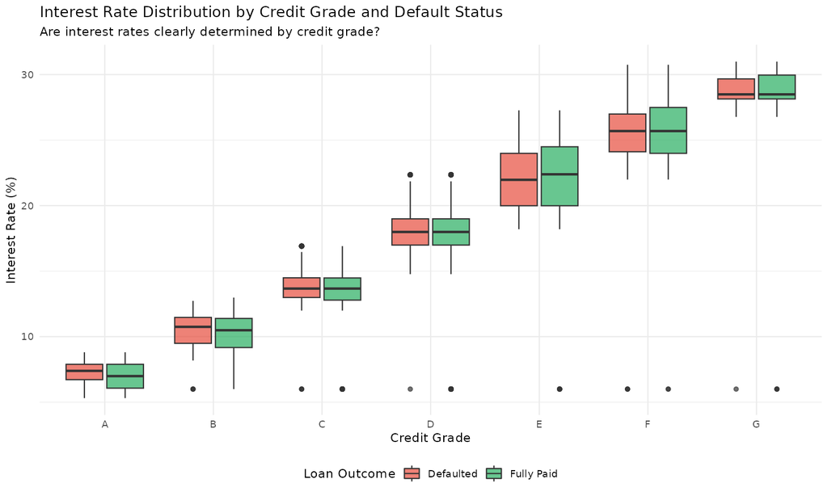

Interest rates rise consistently by grade. Defaulted and fully paid borrowers received virtually identical rates within each grade.

**Findings:**

- Interest rates rise **consistently and clearly** from Grade A (~7-8%) to Grade G (~29-30%)
- Within each grade, the red (Defaulted) and green (Fully Paid) boxes **overlap almost perfectly** — meaning Lending Club cannot distinguish future defaulters from payers at the time of lending
- Interest rates are **not determined by age or occupation** as the Institute believed — grade is the primary driver

**Verdict:** *The Institute’s heuristic that interest rates are determined by age and occupation is not supported.* Credit grade is the overwhelmingly dominant factor in interest rate determination. This is actually evidence of a well-functioning pricing system — higher risk borrowers pay more.

# 8 Default Rate by Loan Purpose

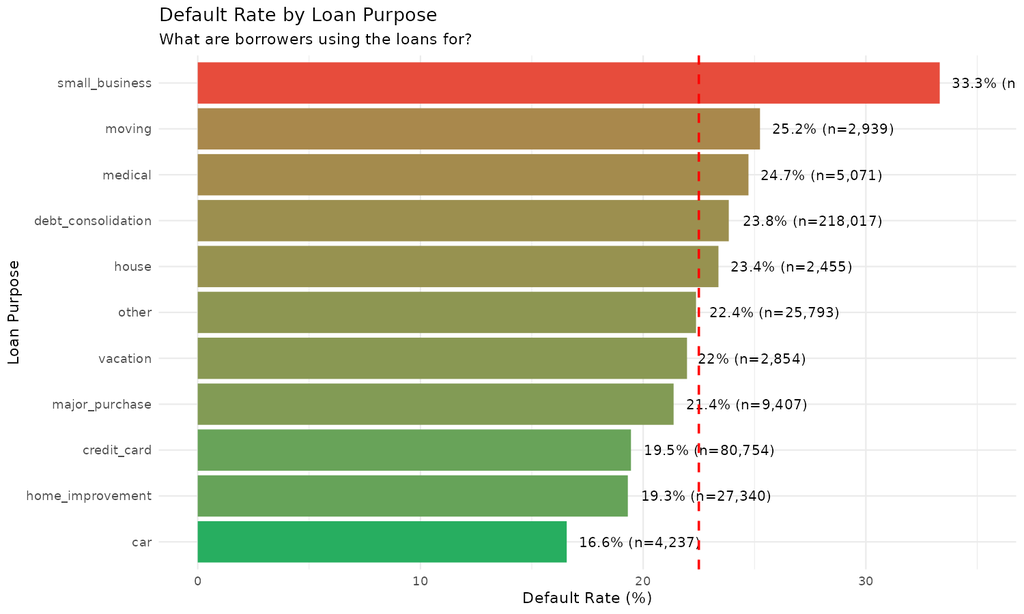

Small business loans carry the highest default risk. Car loans are the safest.

**Findings:**

- **Small business (33.3%)** — highest risk. Business loans are speculative by nature — unlike asset-backed loans, their repayment depends entirely on future business success which is uncertain
- **Car loans (16.6%)** — lowest risk. Backed by a physical asset that can be repossessed; borrowers also tend to be more financially stable
- **Debt consolidation (23.8%, n=218,017)** — above average and the most common loan purpose. Borrowers consolidating debt are already financially stressed — taking a new loan to pay old loans is a warning sign
- **Credit card and home improvement** loans sit below average — associated with more financially stable borrowers

**Recommendation:** Apply stricter screening to small business and debt consolidation loans. These two categories together represent significant portfolio risk.

# 9 Summary: Are the Institute’s Heuristics Realistic?

| Heuristic | Verdict | Evidence |
| --- | --- | --- |
| Home owners default less | Partially supported | Mortgage holders default less (18.8%) but outright owners show no advantage (22.8%) |
| 10+ year employment = lower default | Weakly supported | Only 1.8 point difference — not a reliable predictor |
| Credit grades predict default | Strongly confirmed | Clear staircase from 6.9% (A) to 57.3% (G) |
| Interest rates determined by age/occupation | Not supported | Grade is the primary driver of interest rate |
| States differ significantly in default culture | Not supported | Most states cluster within a narrow 8-point band |

# 10 Recommendations to the Director

1. **Use credit grade as the primary screening tool** — it is the most reliable predictor available, with default rates ranging from 6.9% to 57.3% across grades A to G
2. **Implement a DTI hard cap of 20** for conservative lending — borrowers above this threshold consistently exceed the average default rate
3. **Refine the home ownership heuristic** — focus on mortgage holders specifically rather than all home owners. Outright ownership does not reduce default risk
4. **Do not use employment length as a primary screen** — the effect is too small to be meaningful. Use it only in combination with grade and DTI
5. **Apply stricter screening to small business loans** — at 33.3% default rate, these require additional due diligence or higher interest rate compensation
6. **Treat Texas like any other state** — no special policy adjustments are needed for Texas borrowers
7. **Monitor debt consolidation loans closely** — at 218,017 loans and 23.8% default rate, this category represents the largest absolute default risk in the portfolio

*Data source: Lending Club anonymised loan data. Analysis based on 383,202 resolved loans (Defaulted and Fully Paid) from a total dataset of 1,000,000 loans.*